# Layered Integration Approach for Multi-view Analysis of Real-world Datasets

## 2.4 Noise removal

In this cell we remove the timestamps which we consider as noise. This is illustrated on the image below.

There are 4 methods we use to filter points:

- We remove points which have a negative active power or negative wind speed
- We remove points which have an uncommon wind speed-active power relation (by sparse cubes)
- We remove points which deviate to much from the expected active power on the **positive side** (hypercube approach)
- We remove points which deviate to much from the expected active power on the **negative side** (hypercube approach)

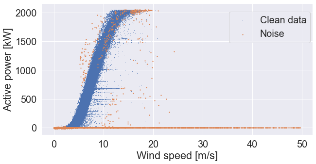

```python
sns.set(font_scale=1)

dict_turbines = sf.remove_noise(dict_turbines_uncleaned, hypercubes,
                                      remove_negative=True, min_cube_count=1, max_pos_deviation=500, max_neg_deviation=-1250)
```

## 2.5 Normalize the parameters

In order to give equal priority to each parameter, they need to be normalized. The normalization is applied separately on each parameter and wind turbine by calculating the min-max score for each of the parameters.

The histograms of the min-max score results of each parameter from the first wind turbine are shown below.

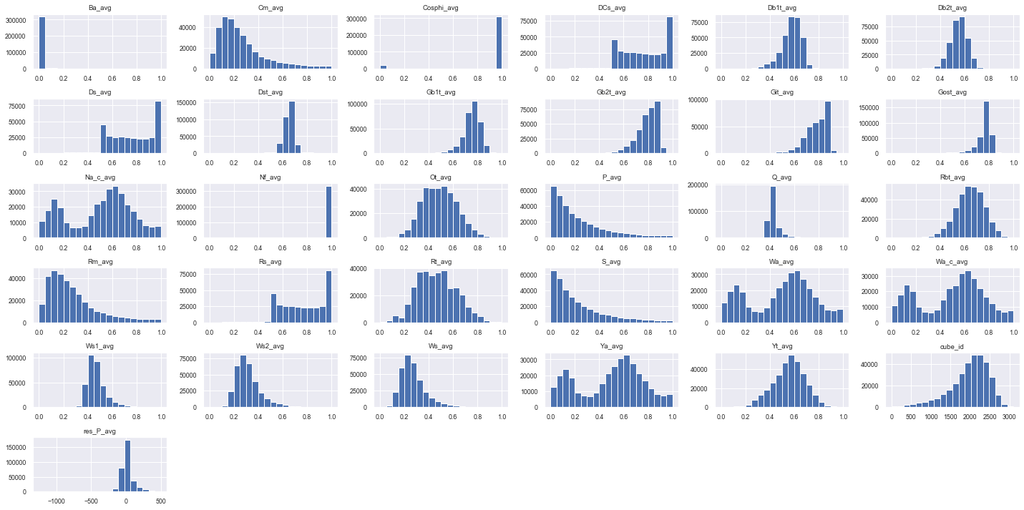

```python
sns.set(font_scale=0.8)

# Select parameters to normalize
parameters = list(df_engie.columns)
parameters.remove('Date_time')
parameters.remove('Wind_turbine_name')

# Make dictionary to separate the NORMALIZED data from each wind turbine:
dict_turbines_norm = {}

for i, turbine in enumerate(turbines):
    df_one_turbine = dict_turbines[turbine].copy()

    for p in parameters:
        df_one_turbine[p] = (df_one_turbine[p] - df_one_turbine[p].min())/(df_one_turbine[p].max() - df_one_turbine[p].min()) #min-max

    dict_turbines_norm[turbine] = df_one_turbine

# Plot the histograms of each feature from the First wind turbine
hist = dict_turbines_norm[turbines[0]].hist(figsize=(20,10), bins=20)
plt.tight_layout()
```

# 3. LAYER 1: Individual analysis

In the proposed layered integration approach, we start with the individual analysis. In here we will cluster the timestamps of each of the 4 wind turbines separately, based on the subset of **operating parameters**. As shown in Section 2.2, this are 12 parameters. This will result in turbine dependent operating modes.

## 3.1 Determine the appropriate amount of clusters per dataset

We use the k-means approach to do each clustering. The initial centers are selected by the smart 'k-means++' approach. Since the k-means++ algorithm still uses a random initial start, we can (and do) repeat it 5 times. Only the best result is used to plot.

For each of the wind turbines, the amount of clusters is determined separately by multiple validation techniques:

```
Calculation of wind turbine 1...
```

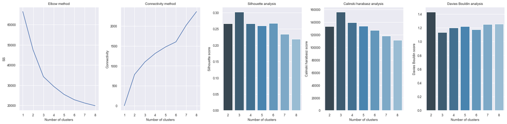

```
Calculation of wind turbine 2...
```

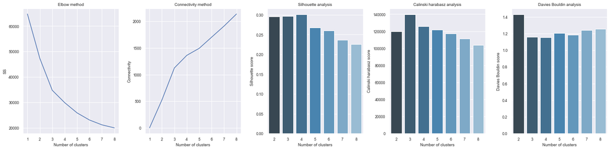

```
Calculation of wind turbine 3...
```

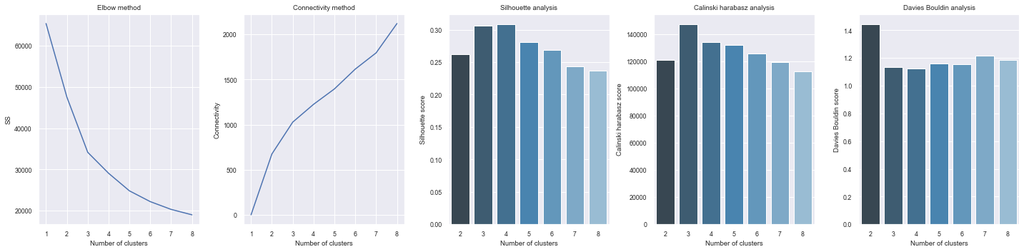

```
Calculation of wind turbine 4...
```

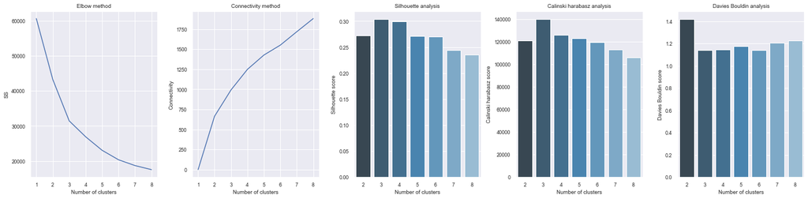

```
	 Elapsed time: 49.18 minutes
```

```python
# ATTENION: this cell takes around 50 minutes to run!
start_time = timeit.default_timer()

for i, turbine in enumerate(turbines):
    print("Calculation of wind turbine " + str(i+1) + "...")
    df_One_norm = dict_turbines_norm[turbine].reset_index()

    sf.plot_kmeans_validation(df_One_norm.loc[:, operational_features], sample_size=0.1)

print("\t Elapsed time: "+ str( np.round((timeit.default_timer() - start_time)/60, 2)) + " minutes")
```

Deciding the proper amount of clusters is a very hard thing to do. We use the majority voting technique based on the results plotted above to decide the optimal amount of clusters per wind turbine. This results in an optimal of 3, 4, 4 and 3 clusters, in the order of the plot.

## 3.2 Compare power curve & torque curve of the obtained operating modes

Based on the most optimal amount of clusters for each dataset, we do the final clusters of the timestamps. Below we plot the power curve, torque curve and amount of points per cluster. Since it is both interesting to see the clusters on a separate plot as in the same plot, both of them are plotted below.

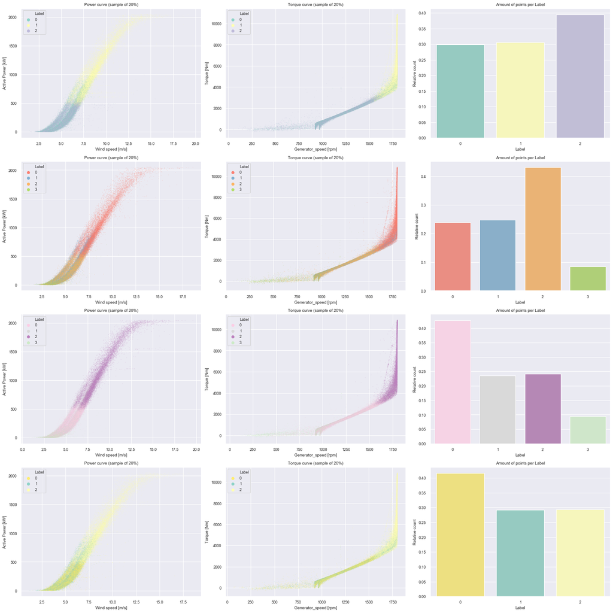

```python
n_clusters = [3, 4, 4, 3]

# Define colors (which will be consitently used during this notebook)
colorpal = sns.color_palette("Set3", np.sum(n_clusters))
pd.set_option('mode.chained_assignment', None)

dict_turbines_norm = sf.do_individual_clustering(turbines, dict_turbines_norm,n_clusters, operational_features, dict_turbines, colorpal)
```

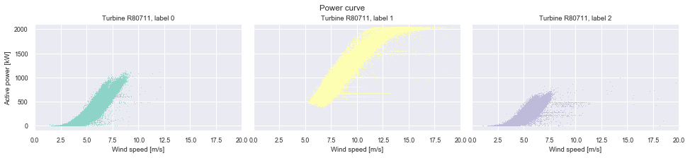

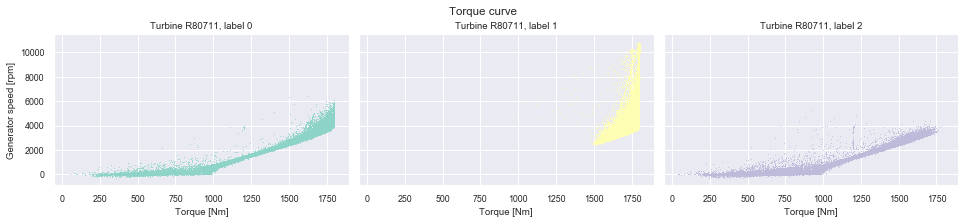

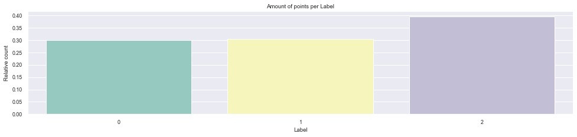

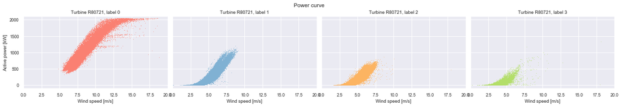

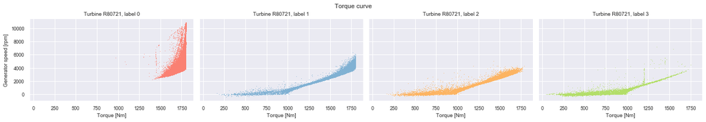

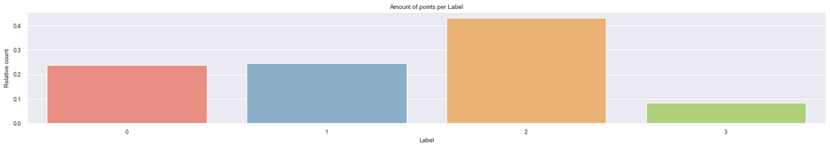

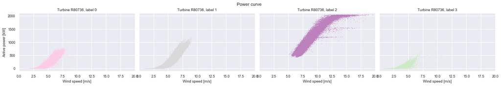

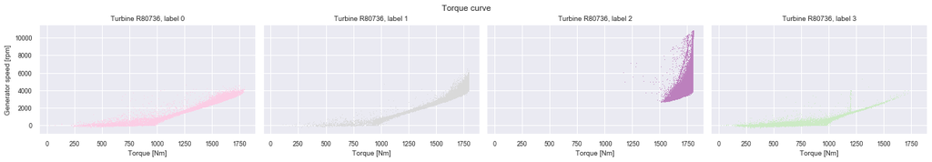

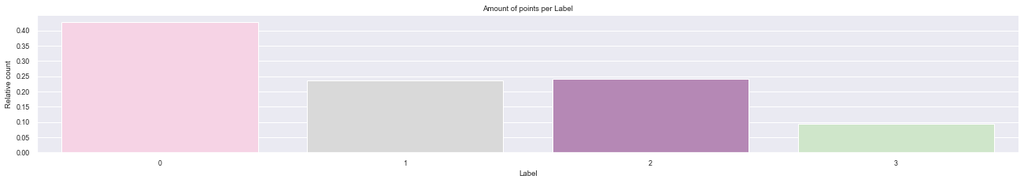

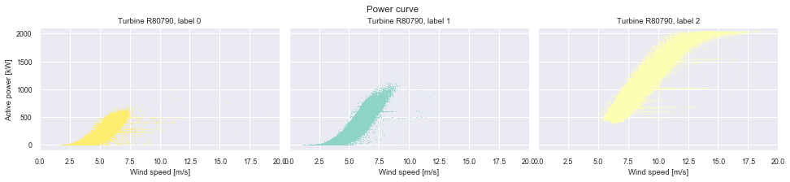

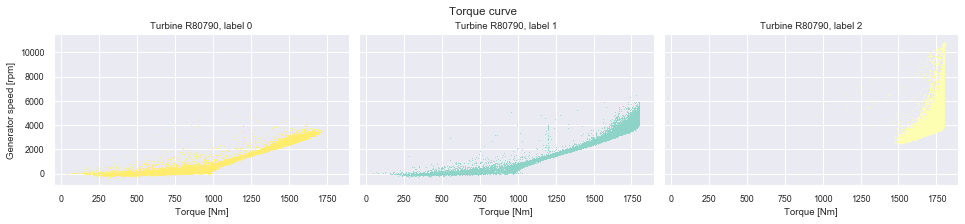

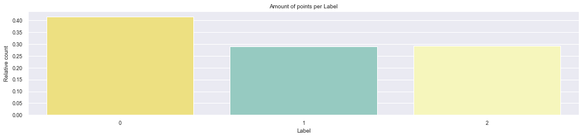

```python
sf.visualize_individual_clustering_per_clusters(colorpal, n_clusters, dict_turbines, turbines)
```